# GARCH and EGARCH volatility forecasting: CAC 40, EURO STOXX 50 and VSTOXX

Author

Malek Dhaouadi

Published

November 3, 2026

Abstract

# 1 Introduction

Financial returns show volatility clustering and, for equity indices, asymmetric responses to negative and positive shocks. GARCH-type models are the standard tool for forecasting conditional volatility and Value-at-Risk. This report asks four questions on the CAC 40 and the EURO STOXX 50:

1. Is there a leverage effect, and does an asymmetric model (EGARCH) fit better than GARCH?
2. Do the models forecast realized volatility as well as the market’s implied volatility (VSTOXX)?
3. Do the models contain information that implied volatility does not (encompassing regressions)?
4. Are one-day VaR and Expected Shortfall forecasts well calibrated, and what fixes under-coverage?

# 2 Data

- CAC 40 (`^FCHI`) adjusted close from Yahoo Finance. In-sample analysis and the one-day evaluation use 2015-01-05 to 2026-10-26 (3,023 returns); the VSTOXX comparison and the VaR work use data from 2000.
- EURO STOXX 50 (`^STOXX50E`), Yahoo Finance, from 2007-04-02.
- VSTOXX (V2TX) daily closes from STOXX, 1999-2026.

Missing prices are dropped, not interpolated. CAC 40 returns (2015-2026) have skewness -0.83 and excess kurtosis 11.19 (Jarque-Bera p < 2.2e-16); the Ljung-Box test on squared returns rejects at all lags tested.

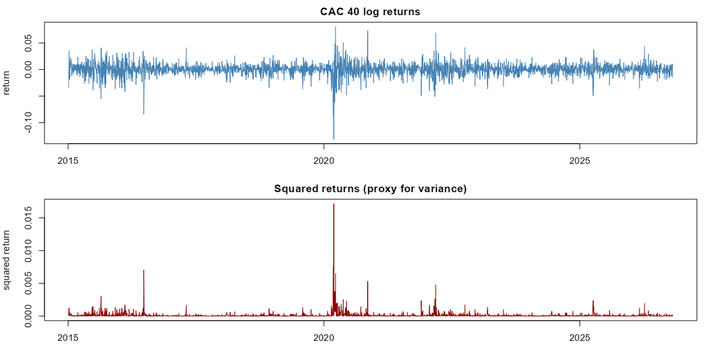

Figure 1: CAC 40 returns and squared returns

# 3 Methods

## 3.1 Models

With $r_t = \mu + \varepsilon_t$, $\varepsilon_t = \sigma_t z_t$ and $z_t$ standardized Student-t:

$$\sigma_t^2 = \omega + \alpha\,\varepsilon_{t-1}^2 + \beta\,\sigma_{t-1}^2 \qquad \text{(GARCH)}$$

$$\ln\sigma_t^2 = \omega + \beta\ln\sigma_{t-1}^2 + \alpha_1 z_{t-1} + \gamma_1\left(|z_{t-1}| - E|z|\right) \qquad \text{(EGARCH, rugarch notation)}$$

Models are estimated by maximum likelihood with `rugarch`. A negative $\alpha_1$ means negative shocks raise volatility more than positive ones.

## 3.2 Out-of-sample design

Rolling estimation with a moving window of 1,000 days (2,000 days in the tail experiment), parameters re-estimated every 50 days. Forecast evaluation uses QLIKE and squared-error losses, Diebold-Mariano tests, and Newey-West (HAC) variances where forecast windows overlap.

## 3.3 Comparison with implied volatility

VSTOXX is a 30-calendar-day implied volatility, so model forecasts are averaged over the next 21 trading days. Realized volatility is measured over the 21 trading days after each forecast origin. The variance risk premium is VSTOXX minus subsequent realized volatility. Encompassing regressions regress realized volatility on VSTOXX and a model forecast, with Newey-West standard errors (lag 20, with lag 40 as a check).

## 3.4 VaR and Expected Shortfall

One-day 1%, 2.5% and 5% VaR and ES. Tests: Kupiec (coverage), Christoffersen (independence), dynamic quantile, and a McNeil-Frey exceedance-residual test for ES, plus tick loss with Diebold-Mariano tests. A tail experiment varies the mean (constant or zero), the distribution (Student-t or skewed Student-t), the window (1,000 or 2,000 days) and the tail estimate (parametric or filtered historical simulation). Candidates are ranked on 2008-2016 by the mean of |log(exceedance rate / nominal level)| at 1% and 5%, a rule fixed before running, and reported on 2017-2026, which is not used for selection.

# 4 Results

## 4.1 In-sample fit

Table 1: GARCH(1,1) with Student-t innovations, CAC 40 2015-2026 (robust standard errors).

| param | Estimate | Std. Error | t value | Pr(>\|t\|) |
| --- | --- | --- | --- | --- |
| mu | 0.0007 | 0.0001 | 5.2630 | 0.0000 |
| omega | 0.0000 | 0.0000 | 0.6431 | 0.5202 |
| alpha1 | 0.1410 | 0.0200 | 7.0364 | 0.0000 |
| beta1 | 0.8316 | 0.0540 | 15.4050 | 0.0000 |
| shape | 5.1943 | 0.7030 | 7.3883 | 0.0000 |

Table 2: EGARCH(1,1) with Student-t innovations, CAC 40 2015-2026 (robust standard errors).

| param | Estimate | Std. Error | t value | Pr(>\|t\|) |
| --- | --- | --- | --- | --- |
| mu | 0.0004 | 0.0001 | 2.9291 | 0.0034 |
| omega | -0.2927 | 0.0041 | -71.3355 | 0.0000 |
| alpha1 | -0.1686 | 0.0119 | -14.1893 | 0.0000 |
| beta1 | 0.9692 | 0.0001 | 16789.6250 | 0.0000 |
| gamma1 | 0.1322 | 0.0091 | 14.5887 | 0.0000 |
| shape | 5.6679 | 0.5418 | 10.4617 | 0.0000 |

EGARCH is preferred by AIC (-6.504 vs -6.458), BIC and log-likelihood (9,836 vs 9,766). The leverage term is negative and significant (Table 2). Standardized residuals show no remaining autocorrelation or ARCH effects; the Student-t goodness-of-fit test is rejected.

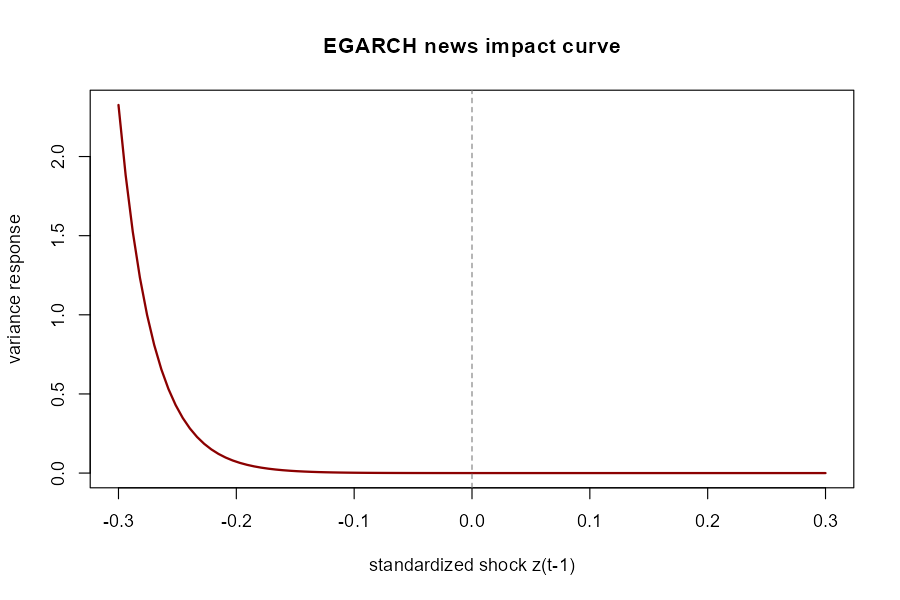

Figure 2: EGARCH news impact curve

## 4.2 One-day out-of-sample forecasts

Table 3: One-day-ahead variance forecasts, CAC 40, last 500 days (squared demeaned return as proxy).

| Loss | GARCH | EGARCH | DM p-value |
| --- | --- | --- | --- |
| QLIKE | 1.438 | 1.427 | 0.67 |
| MSE | 4.252e-08 | 4.02e-08 | 0.016 |

## 4.3 Forecasts against VSTOXX

Table 4: CAC 40 21-day forecasts against VSTOXX by regime (vol points). vrp = VSTOXX minus subsequent realized volatility.

| period | n | vrp | rmse_garch | rmse_egarch | rmse_vstoxx |
| --- | --- | --- | --- | --- | --- |
| 2008-2009 (GFC) | 508 | 3.48 | 12.92 | 15.28 | 13.26 |
| 2010-2012 (euro crisis) | 766 | 4.36 | 8.39 | 7.68 | 8.39 |
| 2013-2019 | 1777 | 3.33 | 6.30 | 5.71 | 6.13 |
| 2020 (COVID) | 255 | 0.86 | 17.13 | 18.45 | 16.54 |
| 2021-2026 | 1463 | 5.13 | 6.96 | 5.76 | 7.45 |

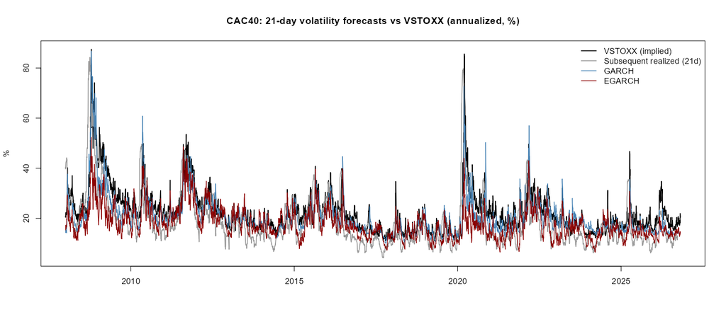

Figure 3: CAC 40: forecasts and VSTOXX

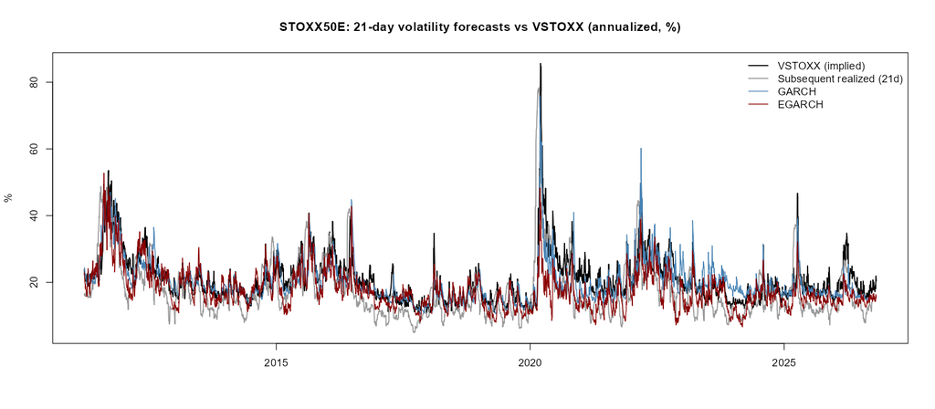

Figure 4: EURO STOXX 50: forecasts and VSTOXX

## 4.4 Encompassing regressions

Table 5: Realized 21-day volatility on VSTOXX and a model forecast (levels, Newey-West lag 20 t-statistics; t40 = lag 40).

| dataset | spec | term | est | t20 | t40 | r2 |
| --- | --- | --- | --- | --- | --- | --- |
| CAC40 | 4: implied + GARCH | implied | 0.769 | 10.358 | 10.242 | 0.476 |
| CAC40 | 4: implied + GARCH | garch | 0.066 | 0.585 | 0.526 | 0.476 |
| CAC40 | 5: implied + EGARCH | implied | 0.763 | 10.959 | 9.867 | 0.476 |
| CAC40 | 5: implied + EGARCH | egarch | 0.104 | 1.414 | 1.314 | 0.476 |
| STOXX50E | 4: implied + GARCH | implied | 0.788 | 9.057 | 9.355 | 0.418 |
| STOXX50E | 4: implied + GARCH | garch | 0.006 | 0.064 | 0.058 | 0.418 |
| STOXX50E | 5: implied + EGARCH | implied | 0.672 | 8.768 | 9.151 | 0.423 |
| STOXX50E | 5: implied + EGARCH | egarch | 0.186 | 1.864 | 1.661 | 0.423 |

VSTOXX remains highly significant when a model forecast is added, while GARCH adds nothing and EGARCH adds at most a little (Table 5).

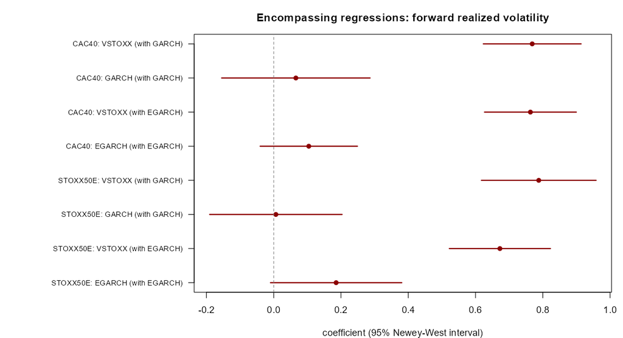

Figure 5: Encompassing regression coefficients

## 4.5 VaR and Expected Shortfall

Table 6: One-day VaR backtest, CAC 40, 2008-2026 (Student-t models, constant mean, 1,000-day window).

| alpha | model | exceed | rate_pct | kupiec_p | indep_p | cc_p | es_p_less | tick_x1e4 |
| --- | --- | --- | --- | --- | --- | --- | --- | --- |
| 0.01 | GARCH | 71 | 1.475 | 0.002 | 0.400 | 0.006 | 0.457 | 4.259 |
| 0.01 | EGARCH | 87 | 1.808 | 0.000 | 0.097 | 0.000 | 0.087 | 4.435 |
| 0.01 | HS250 | 73 | 1.517 | 0.001 | 0.001 | 0.000 | 0.002 | 5.167 |
| 0.05 | GARCH | 317 | 6.588 | 0.000 | 0.002 | 0.000 | 0.071 | 14.601 |
| 0.05 | EGARCH | 289 | 6.006 | 0.002 | 0.168 | 0.003 | 0.000 | 14.469 |
| 0.05 | HS250 | 259 | 5.382 | 0.229 | 0.000 | 0.000 | 0.003 | 16.097 |

Table 7: Tail experiment, hold-out 2017-2026 (candidates not used for selection).

| alpha | candidate | exceed | rate_pct | kupiec_p | dq_p | es_p_less | tick_x1e4 |
| --- | --- | --- | --- | --- | --- | --- | --- |
| 0.010 | sGARCH_mC_std_W1000 / param | 39 | 1.553 | 0.010 | 0.001 | 0.546 | 3.856 |
| 0.010 | sGARCH_m0_sstd_W1000 / param | 26 | 1.035 | 0.861 | 0.014 | 0.703 | 3.858 |
| 0.010 | eGARCH_mC_sstd_W2000 / param | 29 | 1.154 | 0.448 | 0.406 | 0.486 | 3.708 |
| 0.010 | eGARCH_m0_sstd_W2000 / param | 28 | 1.115 | 0.571 | 0.444 | 0.489 | 3.705 |
| 0.010 | HS250 | 40 | 1.592 | 0.006 | 0.000 | 0.042 | 4.641 |
| 0.025 | sGARCH_mC_std_W1000 / param | 98 | 3.901 | 0.000 | 0.000 | 0.645 | 7.677 |
| 0.025 | sGARCH_m0_sstd_W1000 / param | 64 | 2.548 | 0.878 | 0.034 | 0.555 | 7.627 |
| 0.025 | eGARCH_mC_sstd_W2000 / param | 60 | 2.389 | 0.718 | 0.793 | 0.214 | 7.421 |
| 0.025 | eGARCH_m0_sstd_W2000 / param | 59 | 2.349 | 0.624 | 0.809 | 0.247 | 7.420 |
| 0.025 | HS250 | 71 | 2.826 | 0.304 | 0.000 | 0.011 | 8.481 |
| 0.050 | sGARCH_mC_std_W1000 / param | 164 | 6.529 | 0.001 | 0.000 | 0.126 | 12.549 |
| 0.050 | sGARCH_m0_sstd_W1000 / param | 128 | 5.096 | 0.827 | 0.000 | 0.533 | 12.493 |
| 0.050 | eGARCH_mC_sstd_W2000 / param | 121 | 4.817 | 0.672 | 0.028 | 0.279 | 12.149 |
| 0.050 | eGARCH_m0_sstd_W2000 / param | 116 | 4.618 | 0.374 | 0.061 | 0.238 | 12.146 |
| 0.050 | HS250 | 137 | 5.454 | 0.303 | 0.000 | 0.035 | 13.638 |

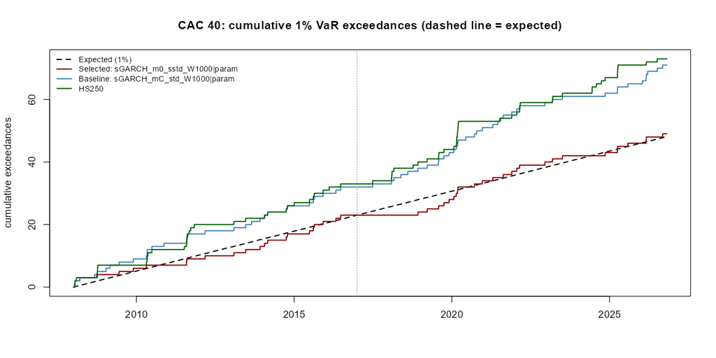

Figure 6: Cumulative 1% VaR exceedances

# 5 Limitations

- 21-day windows overlap: about 185 to 227 independent windows per run, so HAC tests may over-reject.
- The 2008-2009 comparison with VSTOXX uses the CAC 40 as a proxy for the EURO STOXX 50.
- Squared returns are a noisy variance proxy; no intraday realized variance is used.
- Implied volatility is risk-neutral, GARCH is physical-measure.
- 33 VaR candidates were evaluated; the selection tie was broken by listing order; the hold-out has about 25 expected exceedances at 1%.
- Many p-values are reported without multiple-testing adjustment.

# 6 Conclusion

## 7 Reproducibility

Code and data pipeline: scripts `R/01_data.R` to `R/09_encompassing.R`, parameters in `config.yml`, dependencies locked with `renv`. VSTOXX data downloaded from stoxx.com.